# Spatial data in R: Using R as a GIS

A tutorial to perform basic operations with spatial data in R, such as importing and exporting data (both vectorial and raster), plotting, analysing and making maps.

[Francisco Rodriguez-Sanchez](http://sites.google.com/site/rodriguezsanchezf)

v 2.1

18-12-2013

Check out code and latest version at [GitHub](https://github.com/Pakillo/R-GIS-tutorial/blob/master/R-GIS_tutorial.md)

# CONTENTS

1. INTRODUCTION

2. GENERIC MAPPING

- Retrieving base maps from Google with `gmap` function in package `dismo`
- `RgoogleMaps`: Map your data onto Google Map tiles
- `googleVis`: visualise data in a web browser using Google Visualisation API
- `RWorldMap`: mapping global data

3. SPATIAL VECTOR DATA (points, lines, polygons)

- Example dataset: retrieve point occurrence data from GBIF
- Making data 'spatial'
- Define spatial projection
- Quickly plotting point data on a map
- Subsetting and mapping again
- Mapping vectorial data (points, polygons, polylines)
- Drawing polygons and polylines (e.g. for digitising)
- Converting between formats, reading in, and saving spatial vector data
- Changing projection of spatial vector data

4. USING RASTER (GRID) DATA

- Downloading raster climate data from internet
- Loading a raster layer
- Creating a raster stack
- Raster bricks
- Crop rasters
- Define spatial projection of the rasters
- Changing projection
- Plotting raster data
- Spatial autocorrelation
- Extract values from raster
- Rasterize vector data (points, lines or polygons)
- Changing raster resolution
- Spline interpolation
- Setting all rasters to the same extent, projection and resolution all in one
- Elevations, slope, aspect, etc
- Saving and exporting raster data

5. SPATIAL STATISTICS

- Point pattern analysis
- Geostatistics

6. INTERACTING WITH OTHER GIS

7. OTHER USEFUL PACKAGES

8. TO LEARN MORE

# 1. INTRODUCTION

R is great not only for doing statistics, but also for many other tasks, including GIS analysis and working with spatial data. For instance, R is capable of doing wonderful maps such as [this](http://spatialanalysis.co.uk/wp-content/uploads/2012/02/bike_ggplot.png) or [this](http://oscarperpinan.github.io/spacetime-vis/images/airMadrid_stamen.png). In this tutorial I will show some basic GIS functionality in R.

#### Basic packages

```r
library(sp)  # classes for spatial data
library(raster)  # grids, rasters
library(rasterVis)  # raster visualisation
library(maptools)
library(rgeos)
# and their dependencies
```

There are many other useful packages, e.g. check [CRAN Spatial Task View](http://cran.r-project.org/web/views/Spatial.html). Some of them will be used below.

Back to Contents

# 2. GENERIC MAPPING

## Retrieving base maps from Google with `gmap` function in package `dismo`

Some examples:

Getting maps for countries:

[figure not shown]

```r
library(dismo)

mymap <- gmap("France")  # choose whatever country
plot(mymap)
```

Choose map type:

[figure not shown]

```r
mymap <- gmap("France", type = "satellite")
plot(mymap)
```

Choose zoom level:

[figure not shown]

```r
mymap <- gmap("France", type = "satellite", exp = 3)
plot(mymap)
```

Save the map as a file in your working directory for future use

```r
mymap <- gmap("France", type = "satellite", filename = "France.gmap")
```

Now get a map for a region drawn at hand

```r
mymap <- gmap("Europe")
plot(mymap)

select.area <- drawExtent()
# now click 2 times on the map to select your region
mymap <- gmap(select.area)
plot(mymap)
# See ?gmap for many other possibilities
```

## `RgoogleMaps`: Map your data onto Google Map tiles

```r
library(RgoogleMaps)
```

Get base maps from Google (a file will be saved in your working directory)

```r
newmap <- GetMap(center = c(36.7, -5.9), zoom = 10, destfile = "newmap.png",
    maptype = "satellite")

# Now using bounding box instead of center coordinates:
newmap2 <- GetMap.bbox(lonR = c(-5, -6), latR = c(36, 37), destfile = "newmap2.png",
    maptype = "terrain")

# Try different maptypes
newmap3 <- GetMap.bbox(lonR = c(-5, -6), latR = c(36, 37), destfile = "newmap3.png",
    maptype = "satellite")
```

Now plot data onto these maps, e.g. these 3 points

[figure not shown]

```r
PlotOnStaticMap(lat = c(36.3, 35.8, 36.4), lon = c(-5.5, -5.6, -5.8), zoom = 10,
    cex = 4, pch = 19, col = "red", FUN = points, add = F)
```

## `googleVis`: visualise data in a web browser using Google Visualisation API

```r
library(googleVis)
```

Run `demo(googleVis)` to see all the possibilities

### Example: plot country-level data

```r
data(Exports)    # a simple data frame
Geo <- gvisGeoMap(Exports, locationvar="Country", numvar="Profit",
                  options=list(height=400, dataMode='regions'))
plot(Geo)
```

Using `print(Geo)` we can get the HTML code to embed the map in a web page!

### Example: Plotting point data onto a google map (internet)

```r
data(Andrew)
M1 <- gvisMap(Andrew, "LatLong", "Tip",
              options=list(showTip=TRUE, showLine=F, enableScrollWheel=TRUE,
                           mapType='satellite', useMapTypeControl=TRUE, width=800,height=400))
plot(M1)
```

## `RWorldMap`: mapping global data

Some examples

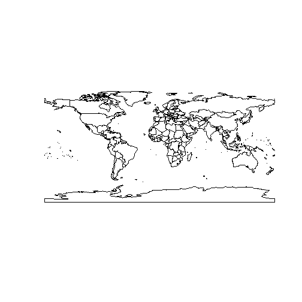

```r
library(rworldmap)

newmap <- getMap(resolution = "coarse")  # different resolutions available
plot(newmap)
```

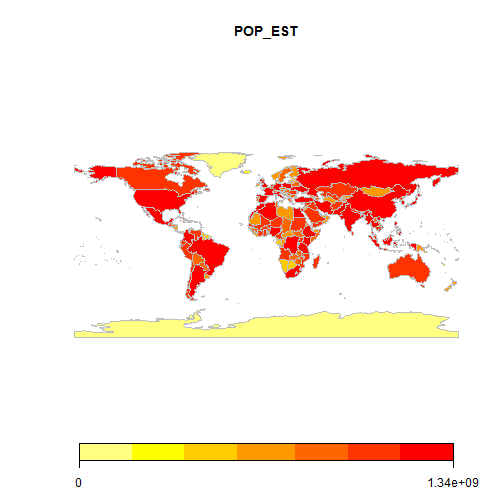

```r
mapCountryData()
```

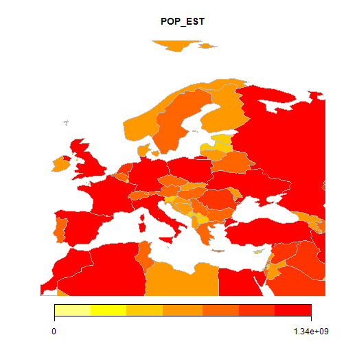

```r
mapCountryData(mapRegion = "europe")
```

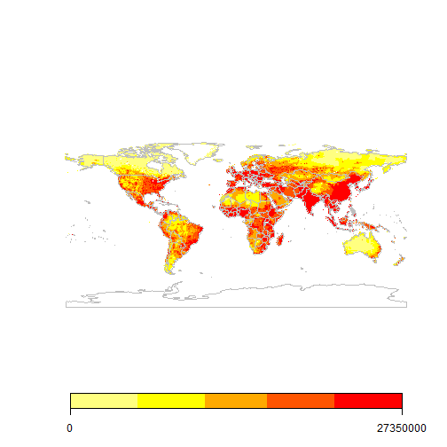

```r
mapGriddedData()
```

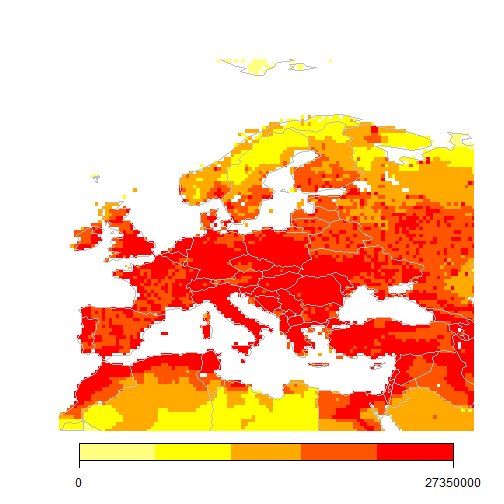

```r
mapGriddedData(mapRegion = "europe")
```

Back to Contents

# 3. SPATIAL VECTOR DATA (points, lines, polygons)

### Example dataset: retrieve point occurrence data from GBIF

Let's create an example dataset: retrieve occurrence data for the laurel tree (Laurus nobilis) from the [Global Biodiversity Information Facility (GBIF)](http://gbif.org)

```r
library(dismo)  # check also the nice 'rgbif' package!
laurus <- gbif("Laurus", "nobilis")
```

```
## Laurus nobilis : 2120 occurrences found
## 1-1000-2000-2120
```

```r
# get data frame with spatial coordinates (points)
locs <- subset(laurus, select = c("country", "lat", "lon"))
head(locs)  # a simple data frame with coordinates
```

```
##   country   lat    lon
## 1   Spain 36.12 -5.579
## 2   Spain 38.26 -5.207
## 3   Spain 36.11 -5.534
## 4   Spain 36.87 -5.312
## 5   Spain 37.30 -1.918
## 6   Spain 36.10 -5.545
```

```r
# Discard data with errors in coordinates:
locs <- subset(locs, locs$lat < 90)
```

### Making data 'spatial'

So we have got a simple dataframe containing spatial coordinates. Let's make these data explicitly *spatial*

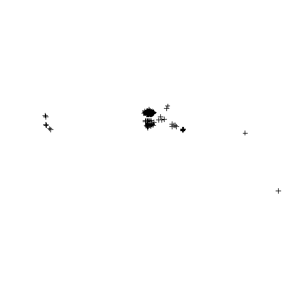

```r
coordinates(locs) <- c("lon", "lat")  # set spatial coordinates
plot(locs)
```

### Define spatial projection

Important: define geographical projection. Consult the appropriate PROJ.4 description here: http://www.spatialreference.org/

```r
crs.geo <- CRS("+proj=longlat +ellps=WGS84 +datum=WGS84")  # geographical, datum WGS84
proj4string(locs) <- crs.geo  # define projection system of our data
summary(locs)
```

```
## Object of class SpatialPointsDataFrame
## Coordinates:
##         min    max
## lon -123.25 145.04
## lat  -37.78  59.84
## Is projected: FALSE
## proj4string :
## [+proj=longlat +ellps=WGS84 +datum=WGS84 +towgs84=0,0,0]
## Number of points: 2109
## Data attributes:
##    Length     Class      Mode
##      2109 character character
```

### Quickly plotting point data on a map

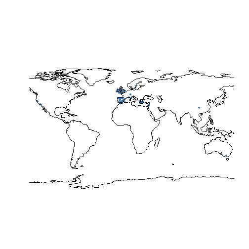

```r
plot(locs, pch = 20, col = "steelblue")
library(rworldmap)
# library rworldmap provides different types of global maps, e.g:
data(coastsCoarse)
data(countriesLow)
plot(coastsCoarse, add = T)
```

### Subsetting and mapping again

```r
table(locs$country)  # see localities of Laurus nobilis by country
```

[output not shown]

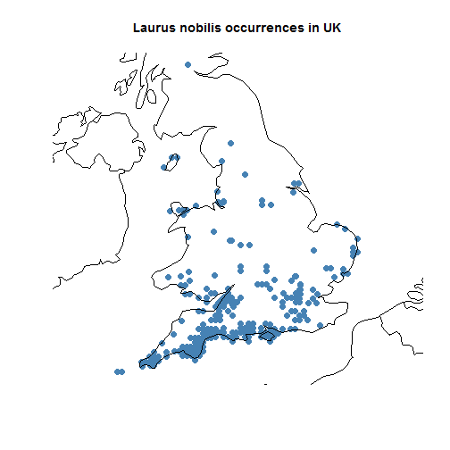

```r
locs.gb <- subset(locs, locs$country == "United Kingdom")  # select only locs in UK
plot(locs.gb, pch = 20, cex = 2, col = "steelblue")
title("Laurus nobilis occurrences in UK")
plot(countriesLow, add = T)
```

```r
summary(locs.gb)
```

```
## Object of class SpatialPointsDataFrame
## Coordinates:
##        min    max
## lon -6.392  1.772
## lat 49.951 56.221
## Is projected: FALSE
## proj4string :
## [+proj=longlat +ellps=WGS84 +datum=WGS84 +towgs84=0,0,0]
## Number of points: 578
## Data attributes:
##    Length     Class      Mode
##       578 character character
```

## Mapping vectorial data (points, polygons, polylines)

### Mapping vectorial data using `gmap` from `dismo`

```r
gbmap <- gmap(locs.gb, type = "satellite")
locs.gb.merc <- Mercator(locs.gb)  # Google Maps are in Mercator projection.
# This function projects the points to that projection to enable mapping
plot(gbmap)
```

[figure not shown]

```r
points(locs.gb.merc, pch = 20, col = "red")
```

### Mapping vectorial data with `RgoogleMaps`

[figure not shown]

```r
require(RgoogleMaps)

locs.gb.coords <- as.data.frame(coordinates(locs.gb))  # retrieves coordinates
# (1st column for longitude, 2nd column for latitude)
PlotOnStaticMap(lat = locs.gb.coords$lat, lon = locs.gb.coords$lon, zoom = 5,
    cex = 1.4, pch = 19, col = "red", FUN = points, add = F)
```

Download base map from Google Maps and plot onto it

```r
map.lim <- qbbox(locs.gb.coords$lat, locs.gb.coords$lon, TYPE = "all")  # define region
# of interest (bounding box)
mymap <- GetMap.bbox(map.lim$lonR, map.lim$latR, destfile = "gmap.png", maptype = "satellite")
```

```
## [1] "http://maps.google.com/maps/api/staticmap?center=53.086237,-2.30987445&zoom=6&size=640x640&maptype=satellite&format=png32&sensor=true"
```

[figure not shown]

```r
# see the file in the wd
PlotOnStaticMap(mymap, lat = locs.gb.coords$lat, lon = locs.gb.coords$lon, zoom = NULL,
    cex = 1.3, pch = 19, col = "red", FUN = points, add = F)
```

Using different background (base map)

```r
mymap <- GetMap.bbox(map.lim$lonR, map.lim$latR, destfile = "gmap.png", maptype = "hybrid")
```

```
## [1] "http://maps.google.com/maps/api/staticmap?center=53.086237,-2.30987445&zoom=6&size=640x640&maptype=hybrid&format=png32&sensor=true"
```

[figure not shown]

```r
PlotOnStaticMap(mymap, lat = locs.gb.coords$lat, lon = locs.gb.coords$lon, zoom = NULL,
    cex = 1.3, pch = 19, col = "red", FUN = points, add = F)
```

### Map vectorial data with `googleVis` (internet)

```r
points.gb <- as.data.frame(locs.gb)
points.gb$latlon <- paste(points.gb$lat, points.gb$lon, sep=":")
map.gb <- gvisMap(points.gb, locationvar="latlon", tipvar="country",
                  options = list(showTip=T, showLine=F, enableScrollWheel=TRUE,
                           useMapTypeControl=T, width=1400,height=800))
plot(map.gb)
```

```r
#print(map.gb)    # get HTML suitable for a webpage
```

### Drawing polygons and polylines (e.g. for digitising)

```r
plot(gbmap)
mypolygon <- drawPoly()  # click on the map to draw a polygon and press ESC when finished
summary(mypolygon)  # now you have a spatial polygon! Easy, isn't it?
```

## Converting between formats, reading in, and saving spatial vector data

### Exporting KML (Google Earth)

```r
writeOGR(locs.gb, dsn = "locsgb.kml", layer = "locs.gb", driver = "KML")
```

### Reading KML

```r
newmap <- readOGR("locsgb.kml", layer = "locs.gb")
```

```
## with 578 features and 2 fields
## Feature type: wkbPoint with 2 dimensions
```

### Save as shapefile

```r
writePointsShape(locs.gb, "locsgb")
```

### Reading shapefiles

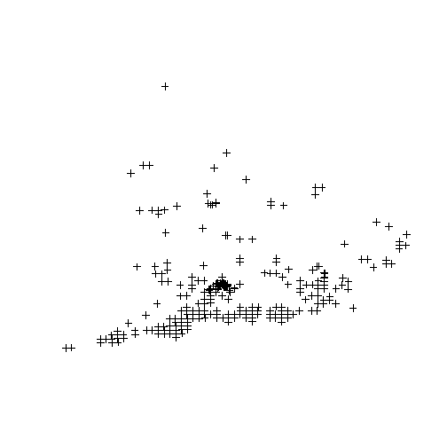

```r
gb.shape <- readShapePoints("locsgb.shp")
plot(gb.shape)
```

Use `readShapePoly` to read polygon shapefiles, and `readShapeLines` to read polylines. See also `shapefile` in `raster` package.

## Changing projection of spatial vector data

`spTransform` (package `sp`) will do the projection as long as the original and new projection are correctly specified.

### Projecting point dataset

To illustrate, let's project the dataframe with Laurus nobilis coordinates that we obtained above:

```r
summary(locs)
```

```
## Object of class SpatialPointsDataFrame
## Coordinates:
##         min    max
## lon -123.25 145.04
## lat  -37.78  59.84
## Is projected: FALSE
## proj4string :
## [+proj=longlat +ellps=WGS84 +datum=WGS84 +towgs84=0,0,0]
## Number of points: 2109
## Data attributes:
##    Length     Class      Mode
##      2109 character character
```

The original coordinates are in lat lon format. Let's define the new desired projection: Lambert Azimuthal Equal Area in this case (look up parameters at http://spatialreference.org)

```r
crs.laea <- CRS("+proj=laea +lat_0=52 +lon_0=10 +x_0=4321000 +y_0=3210000 +ellps=GRS80 +units=m +no_defs")  # Lambert Azimuthal Equal Area
locs.laea <- spTransform(locs, crs.laea)  # spTransform makes the projection
```

### Projecting shapefile of countries

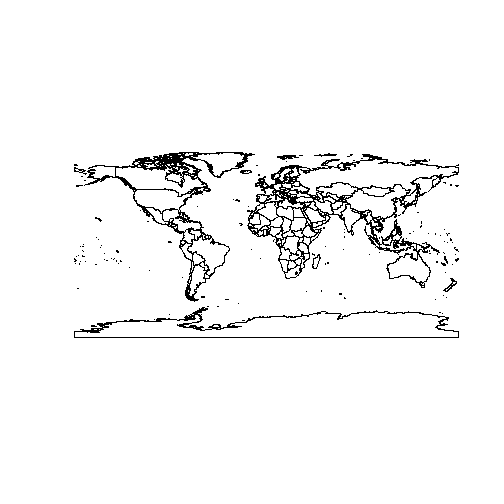

```r
plot(countriesLow)  # countries map in geographical projection
```

```r
country.laea <- spTransform(countriesLow, crs.laea)  # project
```

Let's plot this:

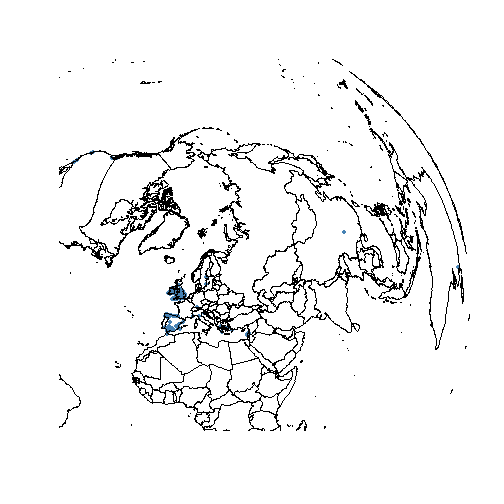

```r
plot(locs.laea, pch = 20, col = "steelblue")
plot(country.laea, add = T)
```

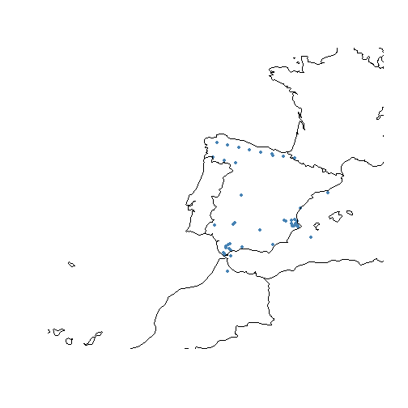

```r
# define spatial limits for plotting
plot(locs.laea, pch = 20, col = "steelblue", xlim = c(1800000, 3900000), ylim = c(1e+06,
    3e+06))
plot(country.laea, add = T)
```

Back to Contents

# 4. USING RASTER (GRID) DATA

### Downloading raster climate data from internet

The `getData` function from the `dismo` package will easily retrieve climate data, elevation, administrative boundaries, etc. Check also the excellent [rWBclimate package](http://ropensci.org/packages/rwbclimate.html) by rOpenSci with additional functionality.

```r
tmin <- getData("worldclim", var = "tmin", res = 10)  # this will download
# global data on minimum temperature at 10' resolution
```

### Loading a raster layer

```r
tmin1 <- raster(paste(getwd(), "/wc10/tmin1.bil", sep = ""))  # Tmin for January
```

Easy! The `raster` function reads many different formats, including Arc ASCII grids or netcdf files (see raster help). And values are stored on disk instead of memory! (useful for large rasters)

```r
fromDisk(tmin1)
```

```
## [1] TRUE
```

Let's examine the raster layer:

```r
tmin1 <- tmin1/10  # Worldclim temperature data come in decimal degrees
tmin1  # look at the info
```

```
## class       : RasterLayer
## dimensions  : 900, 2160, 1944000  (nrow, ncol, ncell)
## resolution  : 0.1667, 0.1667  (x, y)
## extent      : -180, 180, -60, 90  (xmin, xmax, ymin, ymax)
## coord. ref. : +proj=longlat +ellps=WGS84 +towgs84=0,0,0,0,0,0,0 +no_defs
## data source : in memory
## names       : tmin1
## values      : -54.7, 26.6  (min, max)
```

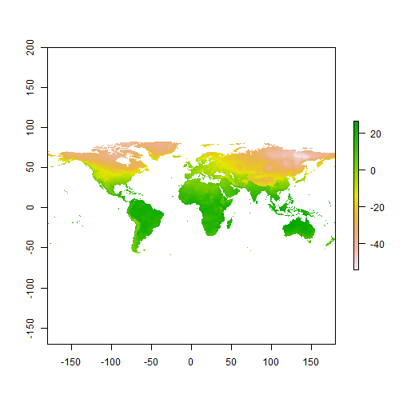

```r
plot(tmin1)
```

### Creating a raster stack

A raster stack is collection of many raster layers with the same projection, spatial extent and resolution. Let's collect several raster files from disk and read them as a single raster stack:

```r
library(gtools)
file.remove(paste(getwd(), "/wc10/", "tmin_10m_bil.zip", sep = ""))
```

```
## [1] TRUE
```

```r
list.ras <- mixedsort(list.files(paste(getwd(), "/wc10/", sep = ""), full.names = T,
    pattern = ".bil"))
list.ras  # I have just collected a list of the files containing monthly temperature values
```

```
##  [1] "C:/Users/FRS/Dropbox/R.scripts/my.Rcode/R-GIS tutorial/wc10/tmin1.bil"
##  [2] "C:/Users/FRS/Dropbox/R.scripts/my.Rcode/R-GIS tutorial/wc10/tmin2.bil"
##  [3] "C:/Users/FRS/Dropbox/R.scripts/my.Rcode/R-GIS tutorial/wc10/tmin3.bil"
##  [4] "C:/Users/FRS/Dropbox/R.scripts/my.Rcode/R-GIS tutorial/wc10/tmin4.bil"
##  [5] "C:/Users/FRS/Dropbox/R.scripts/my.Rcode/R-GIS tutorial/wc10/tmin5.bil"
##  [6] "C:/Users/FRS/Dropbox/R.scripts/my.Rcode/R-GIS tutorial/wc10/tmin6.bil"
##  [7] "C:/Users/FRS/Dropbox/R.scripts/my.Rcode/R-GIS tutorial/wc10/tmin7.bil"
##  [8] "C:/Users/FRS/Dropbox/R.scripts/my.Rcode/R-GIS tutorial/wc10/tmin8.bil"
##  [9] "C:/Users/FRS/Dropbox/R.scripts/my.Rcode/R-GIS tutorial/wc10/tmin9.bil"
## [10] "C:/Users/FRS/Dropbox/R.scripts/my.Rcode/R-GIS tutorial/wc10/tmin10.bil"
## [11] "C:/Users/FRS/Dropbox/R.scripts/my.Rcode/R-GIS tutorial/wc10/tmin11.bil"
## [12] "C:/Users/FRS/Dropbox/R.scripts/my.Rcode/R-GIS tutorial/wc10/tmin12.bil"
```

```r
tmin.all <- stack(list.ras)
tmin.all
```

```
## class       : RasterStack
## dimensions  : 900, 2160, 1944000, 12  (nrow, ncol, ncell, nlayers)
## resolution  : 0.1667, 0.1667  (x, y)
## extent      : -180, 180, -60, 90  (xmin, xmax, ymin, ymax)
## coord. ref. : +proj=longlat +ellps=WGS84 +towgs84=0,0,0,0,0,0,0 +no_defs
## names       : tmin1, tmin2, tmin3, tmin4, tmin5, tmin6, tmin7, tmin8, tmin9, tmin10, tmin11, tmin12
## min values  :  -547,  -525,  -468,  -379,  -225,  -170,  -171,  -178,  -192,   -302,   -449,   -522
## max values  :   266,   273,   277,   283,   295,   312,   311,   312,   300,    268,    267,    268
```

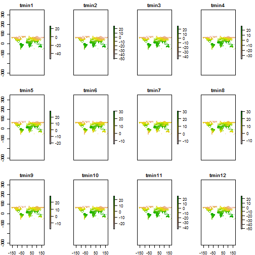

```r
tmin.all <- tmin.all/10
plot(tmin.all)
```

### Raster bricks

A rasterbrick is similar to a raster stack (i.e. multiple layers with the same extent and resolution), but all the data must be stored in a single file on disk.

```r
tmin.brick <- brick(tmin.all)  # creates rasterbrick
```

### Crop rasters

Crop raster manually (drawing region of interest):

```r
plot(tmin1)
newext <- drawExtent()  # click twice on the map to select the region of interest
tmin1.c <- crop(tmin1, newext)
plot(tmin1.c)
```

Alternatively, provide coordinates for the limits of the region of interest:

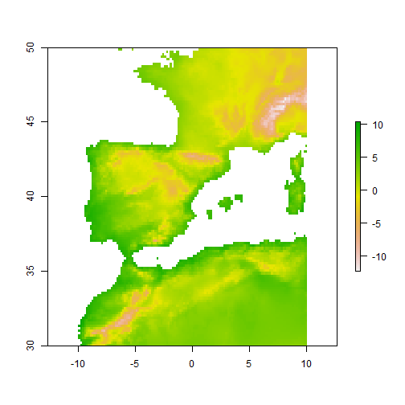

```r
newext <- c(-10, 10, 30, 50)
tmin1.c <- crop(tmin1, newext)
plot(tmin1.c)
```

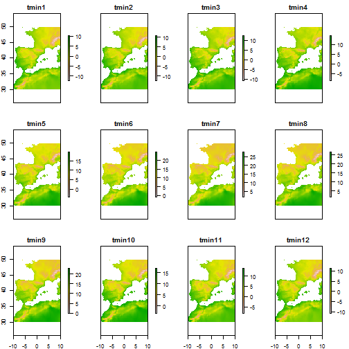

```r
tmin.all.c <- crop(tmin.all, newext)
plot(tmin.all.c)
```

### Define spatial projection of the rasters

```r
crs.geo  # defined above
```

```
## CRS arguments:
##  +proj=longlat +ellps=WGS84 +datum=WGS84 +towgs84=0,0,0
```

```r
projection(tmin1.c) <- crs.geo
projection(tmin.all.c) <- crs.geo
tmin1.c  # notice info at coord.ref.
```

```
## class       : RasterLayer
## dimensions  : 120, 120, 14400  (nrow, ncol, ncell)
## resolution  : 0.1667, 0.1667  (x, y)
## extent      : -10, 10, 30, 50  (xmin, xmax, ymin, ymax)
## coord. ref. : +proj=longlat +ellps=WGS84 +datum=WGS84 +towgs84=0,0,0
## data source : in memory
## names       : tmin1
## values      : -12.3, 10.3  (min, max)
```

### Changing projection

Use `projectRaster` function:

```r
tmin1.proj <- projectRaster(tmin1.c, crs = "+proj=merc +lon_0=0 +k=1 +x_0=0 +y_0=0 +a=6378137 +b=6378137 +units=m +no_defs")  # can also use a template raster, see ?projectRaster
tmin1.proj  # notice info at coord.ref.
```

```
## class       : RasterLayer
## dimensions  : 132, 134, 17688  (nrow, ncol, ncell)
## resolution  : 18600, 24200  (x, y)
## extent      : -1243395, 1249005, 3372876, 6567276  (xmin, xmax, ymin, ymax)
## coord. ref. : +proj=merc +lon_0=0 +k=1 +x_0=0 +y_0=0 +a=6378137 +b=6378137 +units=m +no_defs
## data source : in memory
## names       : tmin1
## values      : -11.59, 10.3  (min, max)
```

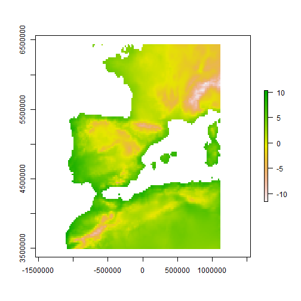

```r
plot(tmin1.proj)
```